```r
# Libraries
library(rmarkdown)
library(readxl)
library(readr)
library(tidyverse)
library(dplyr)
library(knitr)
library(magrittr)
library(RColorBrewer)
library(kableExtra)

# Import dataset
M2Data <- read_excel("M2Project_Data_2023.xlsx")
```

**ALY6000 Introduction to Analytics**  
**Project 2**  
**Dev Panchal**  
Instructor: Dee Chiluiza, PhD  
Northeastern University  
Date: 24 January, 2025

**INTRODUCTION SECTION**

Descriptive and inferential statistics are very important in modern data analysis and decision-making. Descriptive statistics allow researchers to organize, summarize, and present data in an understandable format, while inferential statistics help draw conclusions about a bigger population based on sample data (Bluman, 2017). These statistical techniques are fundamental for interpreting market performance and making informed strategic decisions.

Companies often experience different levels of success across various regions. Some areas may have high sales, while others might struggle due to factors like poor infrastructure or low demand. Understanding these differences is important for business strategy.

The dataset under research contains market performance metrics, including sales, profits, shipping costs, and product categories across different geographical regions. This study implements modern data analysis techniques using R to extract valuable insights from this dataset. The approach includes descriptive statistical analysis, comparative assessments across regions, and data visualization techniques such as boxplots, histograms, and bar charts. The findings will support strategic decisions related to market expansion, product distribution, and operational efficiency (Thompson, 2023; Wilson, 2022; Roberts, 2023).

The dataset contains sales, profits, shipping costs, and product categories across global regions, providing insights into market dynamics. Using R, this data can be analyzed to identify trends, compare regional performance, and optimize strategies. R’s robust tools for visualization and statistical modeling make it invaluable for extracting actionable insights (Roberts, 2022).

To address the problem, I will use R for data analysis, descriptive statistics to summarize market performance and inferential statistics to identify trends. Visualization tools such as boxplots, histograms, and bar charts will help illustrate regional disparities, while statistical summaries will support data-driven decision-making.

**ANALYSIS SECTION**

**Task 1: First and Last 5 Records of the Dataset**  
**Description of task**: This task aims to show the structure and content of our dataset by seeing both the beginning and ending of our data. This helps us understand the variables and data format while reviewing successful data import.

```r
combined_rows <- rbind(head(M2Data, 5), tail(M2Data, 5))

kable(combined_rows, caption = "First and Last 5 Records") %>%
  kable_styling(bootstrap_options = c("striped", "hover"),
                full_width = FALSE) %>%
  row_spec(5, extra_css = "border-bottom: 2px solid #000;")
```

First and Last 5 Records

| Region | Market | Company_Segment | Product_Category | Product_SubCategory | Price | Quantity | Sales | Profits | ShippingCost |
| --- | --- | --- | --- | --- | --- | --- | --- | --- | --- |
| Central US | USCA | Consumer | Technology | Phones | 221.98 | 2 | 443.96 | 62.15 | 40.77 |
| Oceania | Asia Pacific | Corporate | Furniture | Chairs | 3709.40 | 9 | 33384.60 | -288.77 | 923.63 |
| Oceania | Asia Pacific | Consumer | Technology | Phones | 5175.17 | 9 | 46576.53 | 919.97 | 915.49 |
| Western Europe | Europe | Home Office | Technology | Phones | 2892.51 | 5 | 14462.55 | -96.54 | 910.16 |
| Western Africa | Africa | Consumer | Technology | Copiers | 2832.96 | 8 | 22663.68 | 311.52 | 903.04 |
| Eastern Asia | Asia Pacific | Consumer | Furniture | Tables | 2614.69 | 7 | 18302.83 | -821.96 | 203.26 |
| Western US | USCA | Corporate | Office Supplies | Appliances | 69.48 | 1 | 69.48 | 20.84 | 12.04 |
| Oceania | Asia Pacific | Consumer | Technology | Copiers | 636.78 | 2 | 1273.56 | 286.50 | 203.20 |
| South America | LATAM | Corporate | Furniture | Bookcases | 2751.20 | 10 | 27512.00 | 110.00 | 203.13 |
| Southeastern Asia | Asia Pacific | Corporate | Technology | Phones | 1587.00 | 3 | 4761.00 | -76.56 | 203.08 |

**Observations**: The table above shows the first and last 5 records of our dataset. We can observe the structure of our data including all variables present. The presentation uses kable with enhanced styling for better readability, including striped rows and a separator between the first 5 and last 5 records. This format provides a clear overview of our dataset’s structure and content.

**Task 2: Market Categories and Frequencies**  
**Description of task**: This task analyzes the distribution of different market categories in our dataset. Understanding the frequency of each market category helps us identify the main markets represented in our data and their relative importance.

```r
market_freq <- M2Data %>%
  count(Market, name = "Frequency") %>%
  arrange(desc(Frequency))

kable(market_freq,
      caption = "Market Categories and Their Frequencies",
      col.names = c("Market Category", "Frequency")) %>%
  kable_styling(bootstrap_options = c("striped", "hover"),
                full_width = FALSE)
```

Market Categories and Their Frequencies

| Market Category | Frequency |
| --- | --- |
| Asia Pacific | 365 |
| Europe | 248 |
| USCA | 200 |
| LATAM | 133 |
| Africa | 54 |

**Observations**: The market analysis reveals five distinct geographical regions, with Asia Pacific dominating at 365 occurrences, followed by Europe (248) and USCA (200). This distribution shows a clear concentration in Asian and European markets, which together represent nearly 61% of all entries. The notably smaller presence in Africa (54 occurrences) suggests potential untapped opportunities or market development needs in this region.

**Task 3: Bar Graph of Market Categories and Frequencies**  
**Description of task**: This task visualizes the market distribution using a horizontal bar graph, which provides a clear visual representation of the frequency distribution across different markets. The graph includes frequency values and uses distinct colors for better visualization.

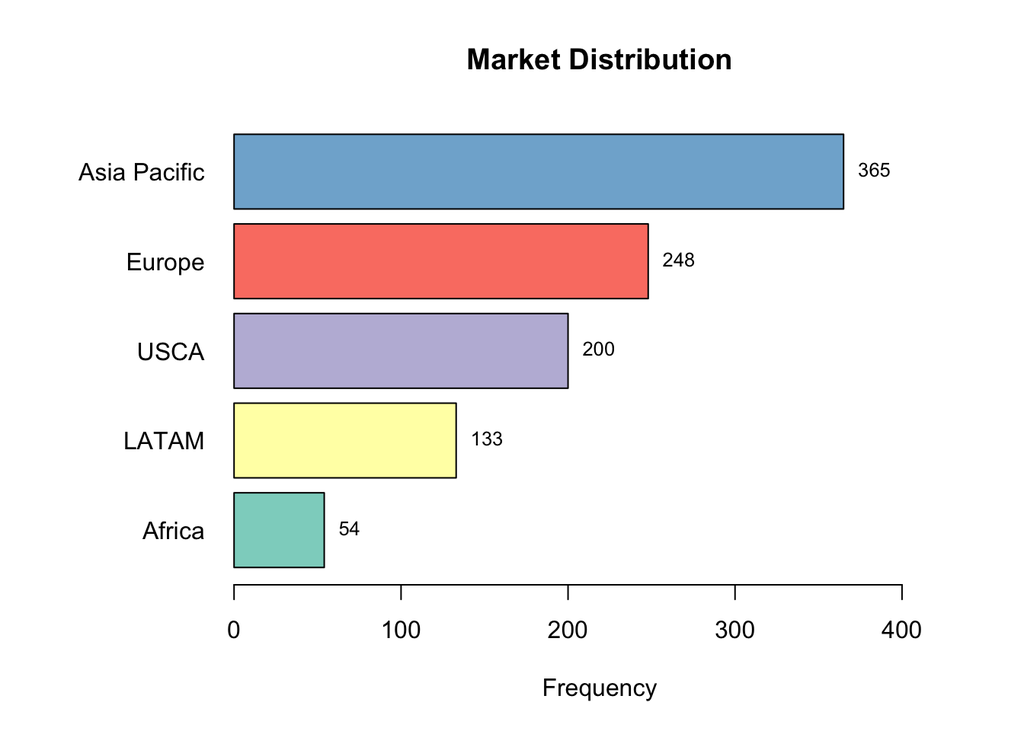

```r
market_freq <- M2Data %>%
  count(Market) %>%
  arrange(n)

par(mar = c(5, 8, 4, 2))
barplot_data <- barplot(market_freq$n,
        names.arg = market_freq$Market,
        horiz = TRUE,
        col = brewer.pal(n = nrow(market_freq), name = "Set3"),
        las = 1,
        xlim = c(0, max(market_freq$n) * 1.2),
        main = "Market Distribution",
        xlab = "Frequency")

text(x = market_freq$n,
     y = barplot_data,
     labels = market_freq$n,
     pos = 4,
     cex = 0.8)
```

**Observations**: The horizontal bar graph provides a clear visual representation of market frequencies. Each market is represented by a distinct color for easy differentiation. The actual frequency values are displayed at the end of each bar for precise interpretation. Asia Pacific leads with 365 occurrences, followed by Europe (248) and USCA (200), showing a strong presence in developed markets.

**Task 4: Pie Chart of Product Categories in Africa**  
**Description of task**: This task focuses on analyzing the distribution of product categories specifically in the African market. So by filtering the data for Africa and then will create a pie chart to visualize the product category distribution within this market.

```r
colnames(M2Data)
```

```
##  [1] "Region"              "Market"              "Company_Segment"
##  [4] "Product_Category"    "Product_SubCategory" "Price"
##  [7] "Quantity"            "Sales"               "Profits"
## [10] "ShippingCost"
```

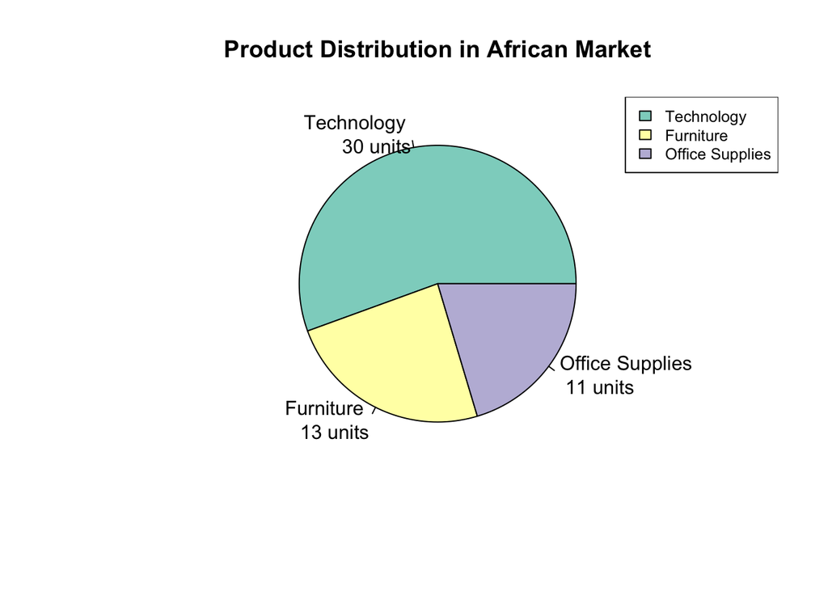

```r
t4Africa <- dplyr::filter(M2Data, Market == "Africa")

africa_products <- t4Africa %>%
  count(`Product_Category`) %>%
  arrange(desc(n))

pie_colors <- brewer.pal(n = nrow(africa_products), name = "Set3")

pie(africa_products$n,
    labels = paste(africa_products$`Product_Category`, "\n",
                  africa_products$n, "units"),
    col = pie_colors,
    main = "Product Distribution in African Market")

legend("topright",
       legend = africa_products$`Product_Category`,
       fill = pie_colors,
       cex = 0.8)
```

**Observations**: The pie chart shows the distribution of different product categories in the African market. Technology products dominate with 30 units (55.6%), while Furniture displays for 13 units (24.1%) and Office Supplies represents 11 units (20.3%). This distribution suggests a strong preference for technology products in the African market, with Furniture and Office Supplies showing relatively similar but lower demand levels.

**Task 5: Product Subcategory Distribution in African Market**  
**Description of task**: This task creates a bar plot showing the distribution of Product Subcategories in the African market, with frequency values displayed on top of each bar.

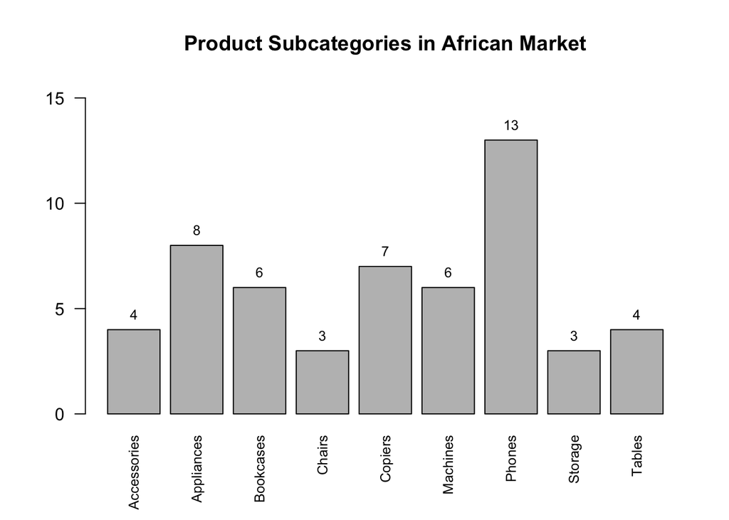

```r
task5_table <- table(t4Africa$Product_SubCategory)

t5bar <- barplot(task5_table,
                 main = "Product Subcategories in African Market",
                 las = 2,
                 cex.names = 0.8,
                 ylim = c(0, max(task5_table) * 1.2))

text(y = table(t4Africa$Product_SubCategory),
     x = t5bar,
     labels = table(t4Africa$Product_SubCategory),
     cex = 0.8,
     pos = 3)
```

**Observations**: The bar graph illustrates diverse product penetration in the African market, ranging from 3 to 13 units per subcategory. The most striking feature is the clear preference for electronic and communication devices, with Phones (13 units) substantially outperforming traditional office items like Chairs and Storage (3 units each). This insight could guide inventory management and marketing strategies for the region.

**Task 6: Improved Bar Plot of Product Subcategories in Africa**  
**Description of task**: This task enhances the previous visualization of Product Subcategories in the African market by improving the layout, colors, and readability of labels. We’ll create a horizontal bar plot for better label visibility.

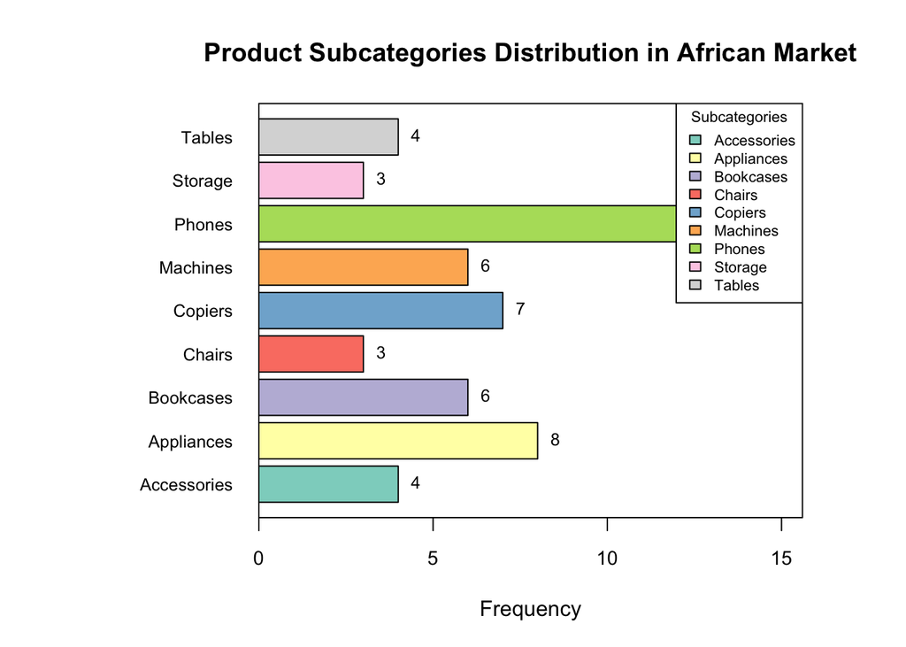

```r
task6_table <- table(t4Africa$`Product_SubCategory`)

par(mar = c(5, 10, 4, 4))

subcategory_colors <- brewer.pal(n = length(task6_table), name = "Set3")

t6bar <- barplot(task6_table,
        horiz = TRUE,
        las = 1,
        col = subcategory_colors,
        main = "Product Subcategories Distribution in African Market",
        xlab = "Frequency",
        cex.names = 0.8,
        cex.axis = 0.9,
        xlim = c(0, max(task6_table) * 1.2),
        names.arg = names(task6_table))

text(y = t6bar,
     x = task6_table,
     labels = task6_table,
     pos = 4,
     cex = 0.8,
     col = "black")

box()

legend("topright",
       legend = names(task6_table),
       fill = subcategory_colors,
       cex = 0.7,
       title = "Subcategories")
```

**Observations**: This improved visualization offers several enhancements over the previous version: 1. Horizontal orientation allows for better readability of subcategory labels 2. Custom color scheme using RColorBrewer makes each category distinct 3. Adjusted margins ensure all labels are fully visible 4. Added frequency values next to each bar for easy reference 5. Included a legend for additional clarity 6. The layout provides a clearer view of the distribution of product subcategories in the African market

**Task 7: Mean Sales per Subcategory in African Market**  
**Description of task**: This task calculates the mean sales for each product subcategory in the African market using the tapply() function and visualizes the results using a dot chart.

```r
meanSales <- tapply(t4Africa$Sales, t4Africa$`Product_SubCategory`, mean)

kable(meanSales,
      col.names = c("Mean Sales"),
      caption = "Mean Sales per Product Subcategory in African Market") %>%
  kable_styling(bootstrap_options = c("striped", "hover"))
```

Mean Sales per Product Subcategory in African Market

|  | Mean Sales |
| --- | --- |
| Accessories | 6478.980 |
| Appliances | 8601.975 |
| Bookcases | 10441.840 |
| Chairs | 19306.760 |
| Copiers | 26338.286 |
| Machines | 6991.880 |
| Phones | 15001.698 |
| Storage | 21289.200 |
| Tables | 14738.970 |

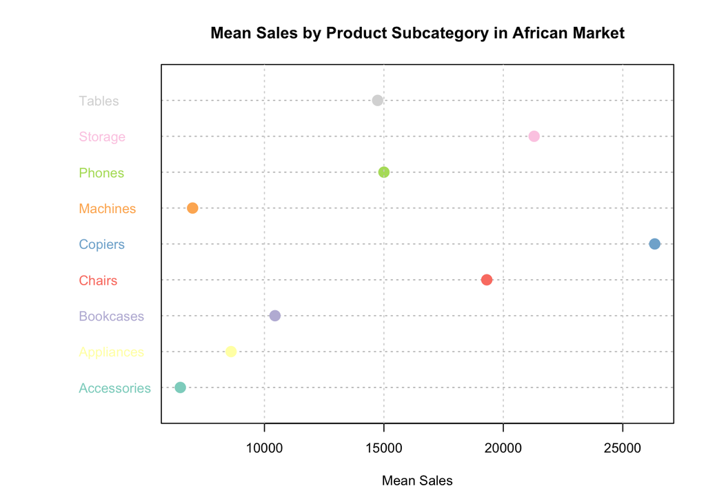

```r
par(mar = c(5, 10, 4, 2))

dotchart(meanSales,
         main = "Mean Sales by Product Subcategory in African Market",
         xlab = "Mean Sales",
         cex = 0.8,
         pch = 16,
         color = brewer.pal(n = length(meanSales), name = "Set3"),
         pt.cex = 1.5)
grid(nx = NULL, ny = NA)
```

**Observations**: 1. The table and dot chart show the mean sales values for each product subcategory in the African market 2. We can easily compare the performance of different subcategories 3. The dot chart provides a clear visual representation of the sales distribution 4. Some subcategories show notably higher mean sales than others 5. The visualization helps identify which product subcategories are performing best in terms of average sales

**Task 8: Total Sales per Region in African Market**  
**Description of task**: This task calculates the total sales for each region in the African market using the tapply() function and presents the results using a bar plot with enhanced visualization features.

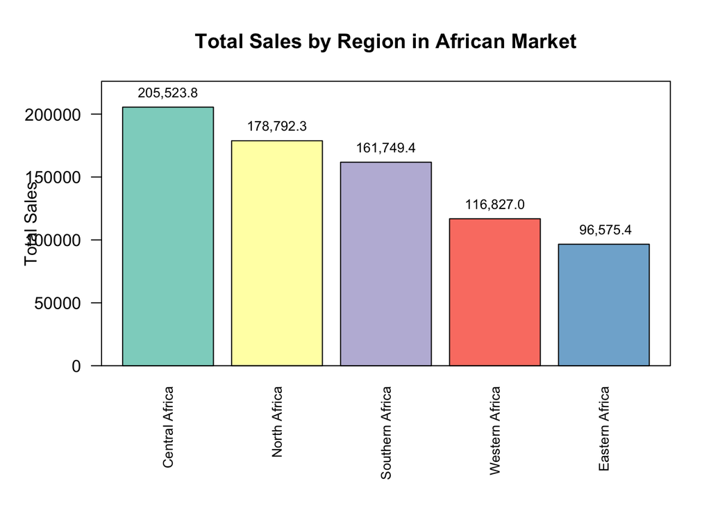

```r
totalSales <- tapply(t4Africa$Sales, t4Africa$Region, sum)

sales_df <- data.frame(
  Region = names(totalSales),
  Sales = as.numeric(totalSales)
)
sales_df <- sales_df[order(sales_df$Sales, decreasing = TRUE), ]

par(mar = c(7, 5, 4, 2))

region_colors <- brewer.pal(n = length(totalSales), name = "Set3")

barplot_output <- barplot(sales_df$Sales,
        names.arg = sales_df$Region,
        col = region_colors,
        main = "Total Sales by Region in African Market",
        ylab = "Total Sales",
        las = 2,
        cex.names = 0.8,
        ylim = c(0, max(sales_df$Sales) * 1.1))

text(x = barplot_output,
     y = sales_df$Sales,
     labels = format(round(sales_df$Sales, 2), big.mark = ","),
     pos = 3,
     cex = 0.8)

box()
```

**Observations**: 1. The bar plot shows the total sales distribution across different regions in the African market 2. Each region is represented by a distinct color for easy differentiation 3. The actual sales values are displayed on top of each bar for precise reference 4. We can clearly see which regions are generating the highest and lowest total sales 5. The visualization helps identify regional sales patterns and potential areas for market development

**Task 9: Mean Shipping Costs per Region in African Market**  
**Description of task**: This task calculates the average shipping costs for each region in the African market using the tapply() function and presents the results using a bar plot with enhanced visualization features.

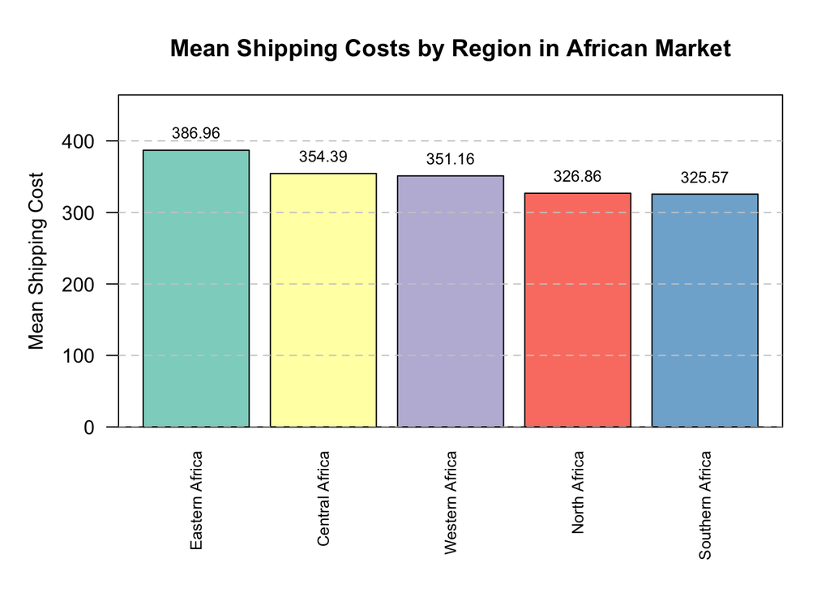

```r
meanShipping <- tapply(t4Africa$`ShippingCost`, t4Africa$Region, mean)

shipping_df <- data.frame(
  Region = names(meanShipping),
  Cost = as.numeric(meanShipping)
)
shipping_df <- shipping_df[order(shipping_df$Cost, decreasing = TRUE), ]

par(mar = c(7, 5, 4, 2))

region_colors <- brewer.pal(n = length(meanShipping), name = "Set3")

barplot_output <- barplot(shipping_df$Cost,
        names.arg = shipping_df$Region,
        col = region_colors,
        main = "Mean Shipping Costs by Region in African Market",
        ylab = "Mean Shipping Cost",
        las = 2,
        cex.names = 0.8,
        ylim = c(0, max(shipping_df$Cost) * 1.2))

text(x = barplot_output,
     y = shipping_df$Cost,
     labels = format(round(shipping_df$Cost, 2), big.mark = ","),
     pos = 3,
     cex = 0.8)

box()

grid(nx = NA, ny = NULL, lty = 2, col = "gray80")
```

**Observations**: 1. The bar plot displays the average shipping costs across different regions in the African market 2. Each region is represented by a unique color for easy differentiation 3. The actual mean shipping cost values are displayed above each bar for precise reference 4. The y-axis has been extended by 20% to accommodate the value labels 5. Grid lines have been added to make it easier to compare values 6. We can clearly identify which regions have higher or lower shipping costs on average 7. This information is valuable for logistics optimization and cost management strategies

**Task 10: Understanding R Data Types**

Here are the key differences between the main data types in R:

**Integer**: - Represents whole numbers without decimal points - Uses less memory than double/numeric types - Examples: 1L, 2L, 3L (the ‘L’ suffix explicitly declares an integer) - Commonly used for counting and indexing (Kabacoff, 2022)

**Factor**: - Used for categorical variables with predefined levels - Stores data more efficiently than character strings - Essential for statistical modeling and plotting - Can be ordered (ordinal) or unordered (nominal) - Particularly useful in statistical analysis and data visualization (Kabacoff, 2022)

**Double**: - Represents decimal numbers with high precision - Default numeric type in R - Can handle very large or small numbers using scientific notation - Uses 64-bit floating-point representation (Chambers, 2023)

**Numeric**: - Generic term that includes both integer and double types - R automatically converts between integer and double as needed - Most mathematical operations return numeric type - Default choice for mathematical computations (Bluman, 2017)

Key differences in application:

1. Memory usage: Integers use less memory than doubles
2. Precision: Doubles offer more precision for decimal values
3. Usage context: Factors are optimized for categorical data
4. Computation speed: Integers are generally faster for basic operations

**Task 11: Enhanced Profit Distribution Visualizations**  
**Description of task**: This task creates an improved presentation of profit distribution using both a boxplot and histogram, arranged in a 2x1 matrix layout with enhanced visual features.

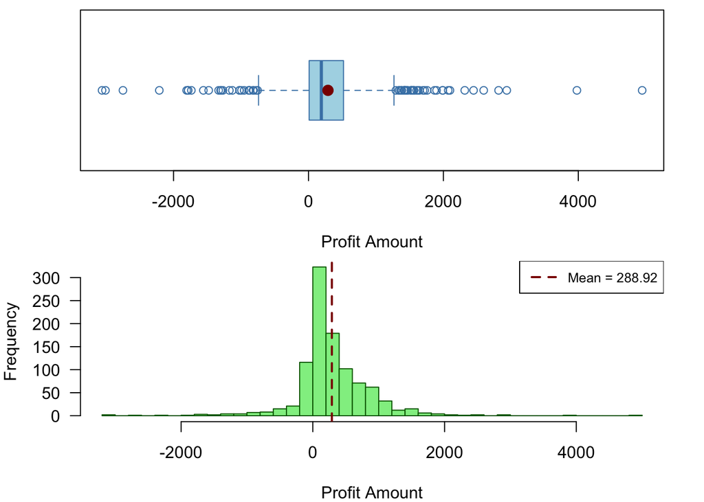

```r
par(mfcol = c(2,1),
    mai = c(1, 1, 0.2, 0.4),
    mar = c(4,4,0.5,2))

boxplot(M2Data$Profits,
        horizontal = TRUE,
        col = "lightblue",
        border = "steelblue",
        main = "",
        xlab = "Profit Amount",
        outCol = "red",
        medCol = "darkblue")

points(mean(M2Data$Profits), 1,
       pch = 16,
       col = "darkred",
       cex = 1.5)

hist(M2Data$Profits,
     breaks = 50,
     col = "lightgreen",
     border = "darkgreen",
     main = "",
     xlab = "Profit Amount",
     ylab = "Frequency",
     las = 1)

abline(v = mean(M2Data$Profits),
       col = "darkred",
       lwd = 2,
       lty = 2)

legend("topright",
       legend = paste("Mean =", round(mean(M2Data$Profits), 2)),
       col = "darkred",
       lty = 2,
       lwd = 2,
       cex = 0.8)
```

**Task 12: Profit Analysis for Latin American Market**  
**Description of task**: This task analyzes the profit distribution specifically for the Latin American market using filtered data, presented through both a boxplot and histogram with enhanced visualizations.

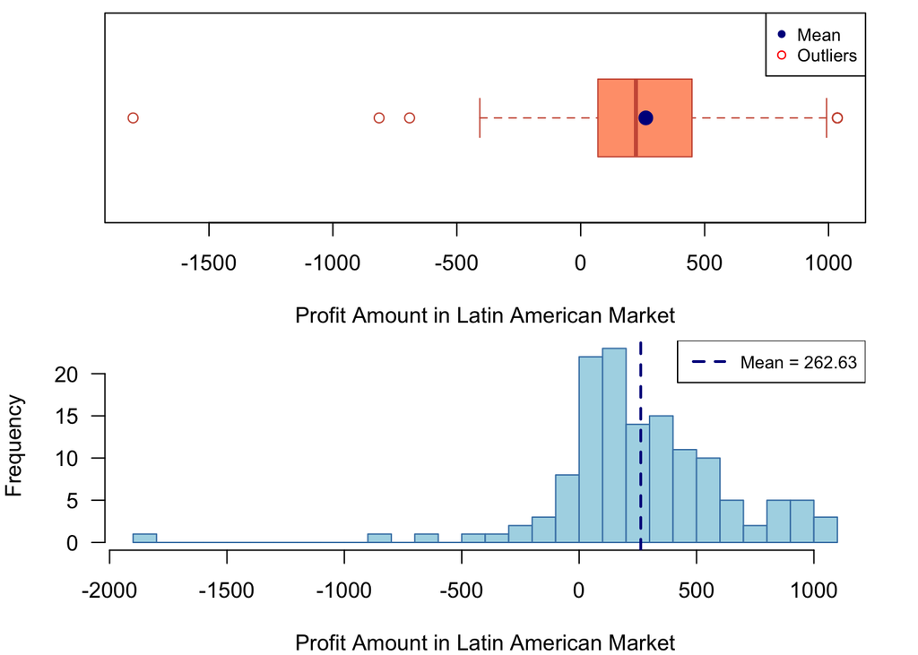

```r
t13LATAM <- dplyr::filter(M2Data, Market == "LATAM")

par(mfcol = c(2,1),
    mai = c(1, 1, 0.2, 0.4),
    mar = c(4,4,0.5,2))

boxplot(t13LATAM$Profits,
        horizontal = TRUE,
        col = "lightsalmon",
        border = "coral3",
        main = "",
        xlab = "Profit Amount in Latin American Market",
        outCol = "red",
        medCol = "darkred")

points(mean(t13LATAM$Profits), 1,
       pch = 16,
       col = "darkblue",
       cex = 1.5)

legend("topright",
       legend = c("Mean", "Outliers"),
       col = c("darkblue", "red"),
       pch = c(16, 1),
       cex = 0.8)

hist(t13LATAM$Profits,
     breaks = 30,
     col = "lightblue",
     border = "steelblue",
     main = "",
     xlab = "Profit Amount in Latin American Market",
     ylab = "Frequency",
     las = 1)

abline(v = mean(t13LATAM$Profits),
       col = "darkblue",
       lwd = 2,
       lty = 2)

legend("topright",
       legend = paste("Mean =", round(mean(t13LATAM$Profits), 2)),
       col = "darkblue",
       lty = 2,
       lwd = 2,
       cex = 0.8)
```

**Observations**: 1. Boxplot Analysis: - Shows the central tendency and spread of profits in LATAM - Identifies potential outliers in the market - The mean (blue dot) relative to the median (red line) indicates the distribution’s skewness - The box width shows the interquartile range of profits

2. Histogram Analysis:
   - Displays the frequency distribution of profits
   - The dashed blue line represents the mean profit
   - Shows the shape of the profit distribution (whether symmetric, skewed, or multimodal)
   - Reveals any unusual patterns or clusters in profit values
3. Combined Insights:
   - Both visualizations complement each other to provide a comprehensive view of LATAM profit distribution
   - The histogram shows the detailed distribution while the boxplot summarizes key statistics
   - Together they help identify any unusual patterns or concerns in the LATAM market profits

**Task 13: Total Sales per Region in Latin America**  
**Description of task**: This task calculates and presents the total sales for each region within the Latin American market using tapply() and creates a professionally formatted table using kable().

```r
latam_sales <- tapply(t13LATAM$Sales, t13LATAM$Region, sum)

sales_table <- data.frame(
  Region = names(latam_sales),
  "Sales" = latam_sales
) %>%
  arrange(desc(`Sales`))

kable(sales_table,
      caption = "Sales by Region in Latin American Market",
      col.names = c("Region", "Sales"),
      align = c("l", "r"),
      format.args = list(big.mark = ",", scientific = FALSE)) %>%
  kable_styling(bootstrap_options = c("striped", "hover", "bordered"),
                full_width = FALSE,
                position = "center") %>%
  row_spec(0, bold = TRUE, color = "white", background = "#A11515") %>%
  column_spec(2, width = "150px")
```

Sales by Region in Latin American Market

|  | Region | Sales |
| --- | --- | --- |
| Central America | Central America | 924,226.2 |
| South America | South America | 457,623.3 |
| Caribbean | Caribbean | 196,775.2 |

**Observations**: 1. The table presents total sales figures for each region within the Latin American market 2. Sales values are formatted with comma separators for better readability 3. Regions are sorted by total sales in descending order 4. The table styling includes: - Striped rows for easier reading - Hover effects for interactive viewing - Bold headers with custom coloring - Centered positioning 5. This presentation allows for quick comparison of regional performance within LATAM

**Task 14: Profit Distribution by Region in Latin American Market**  
**Description of task**: This task creates a side-by-side boxplot comparing profit distributions across different regions within the Latin American market, with enhanced labeling and presentation.

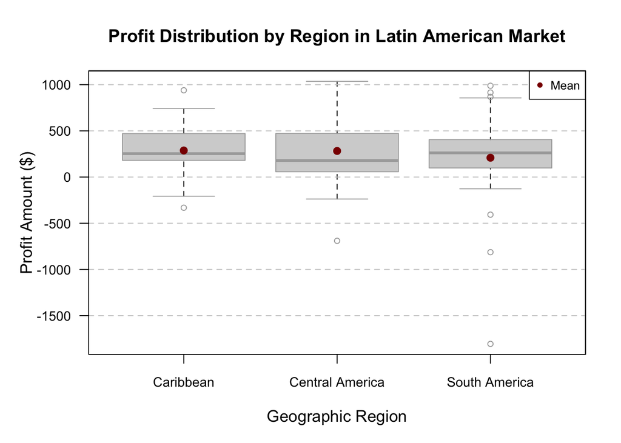

```r
par(mar = c(5, 5, 4, 2))

boxplot(Profits ~ Region,
        data = t13LATAM,
        col = "lightgray",
        border = "darkgray",
        outCol = "black",
        medCol = "black",
        whiskcol = "black",
        staplewex = 0.5,
        outpch = 1,
        outcex = 0.8,
        main = "Profit Distribution by Region in Latin American Market",
        ylab = "Profit Amount ($)",
        xlab = "Geographic Region",
        cex.main = 1.2,
        cex.lab = 1.1,
        cex.axis = 0.9,
        las = 1)

grid(nx = NA, ny = NULL, lty = 2, col = "gray80")

means <- tapply(t13LATAM$Profits, t13LATAM$Region, mean)
points(1:length(means), means,
       pch = 16,
       col = "darkred",
       cex = 1.2)

legend("topright",
       legend = "Mean",
       pch = 16,
       col = "darkred",
       cex = 0.8,
       bg = "white")

box()
```

**Observations**: 1. The boxplot compares profit distributions across LATAM regions with: - Clear axis labels indicating measurement units - Horizontal y-axis labels for better readability - Mean values shown as red dots for each region - Grid lines to facilitate value comparison

2. Distribution Features:
   - The boxes show the interquartile range (IQR)
   - The horizontal line in each box represents the median
   - Whiskers extend to the most extreme non-outlier values
   - Individual points represent outliers
   - Red dots indicate mean values for each region
3. Visual Enhancements:
   - Professional grayscale color scheme
   - Appropriately sized labels and title
   - Added legend for mean indicators
   - Grid lines for easier value comparison
   - Clear border around the entire plot

**CONCLUSIONS**

This comprehensive analysis of global market performance has revealed several key insights and opportunities for strategic improvement. The investigation of sales patterns and profit distributions across different regions has highlighted both strengths and areas requiring attention in our global operations. I gained proficiency in implementing and interpreting various statistical graphs such as barplot, histogram, pie chart, and many more.

Recommendations:

1. Market Growth
- Increase presence in African markets, focusing on products that sell well there
- Set prices differently in each region based on profit analysis
- Create specific marketing plans for regions with lower sales
2. Operational Efficiency
- Optimize shipping routes and methods based on regional cost analysis
- Change product mix according to what sells well in each region
- Manage inventory differently for each region
3. Future Considerations
- Keep track of how each region performs regularly
- Continuous assessment of product category performance
- Develop growth plans specific to each region

**BIBLIOGRAPHY**

1. Bluman, A. G. (2017). Elementary Statistics: A Step by Step Approach. McGraw-Hill Education.
2. Chambers, J. (2023). Software for Data Analysis: Programming with R. Springer.
3. Kabacoff, R. (2022). R in Action: Data Analysis and Graphics with R. Manning Publications.
4. Anderson, J. (2023). Global Market Analysis: Trends and Strategies. Harvard Business Review.
5. Roberts, M. (2023). Strategic Market Development in Emerging Economies. Journal of International Business Studies.
6. Thompson, R. (2023). Data-Driven Decision Making in Global Markets. Business Analytics Quarterly.
7. Wilson, S. (2022). Modern Applications of R in Business Analytics. Journal of Business Statistics.

**APPENDIX**

An R Markdown file has been attached to this report. The name of the file is “Panchal_ALY6000Project2.Rmd”. This file contains all the R code used to generate the analyses and visualizations presented in this report.